# Analysis for Figure 2 of ASK1 inhibits browning of white adipose tissue in obesity

Jeffrey A. Walker

9/2/2020

# Analysis for Figure 2 of “ASK1 inhibits browning of white adipose tissue in obesity”

```r
knitr::opts_chunk$set(echo = FALSE)

# wrangling packages
library(here)
library(janitor)
library(readxl)
library(data.table)
library(stringr)

# analysis packages
library(emmeans)
library(car) # qqplot, spreadlevel
library(DHARMa)

# graphing packages
library(ggsci)
library(ggpubr)
library(ggforce)
library(cowplot)
library(lazyWeave) #pvalstring

here <- here::here
data_path <- "data"

ggplotsci_path <- here("R", "ggplotsci.R")
source(ggplotsci_path)
```

Data source: [ASK1 inhibits browning of white adipose tissue in obesity](https://www.nature.com/articles/s41467-020-15483-7)

This chunk assigns the path to the Excel data file for all panels of Figure 2. The data for each panel are in a single sheet in the Excel file named “Source Date_Figure 2”.

## useful functions

A function to import longitudinal data from Fig 2

## figure 2b – effect of ASK1 KO on growth (body weight)

### figure 2b – import

### figure 2b – exploratory plots

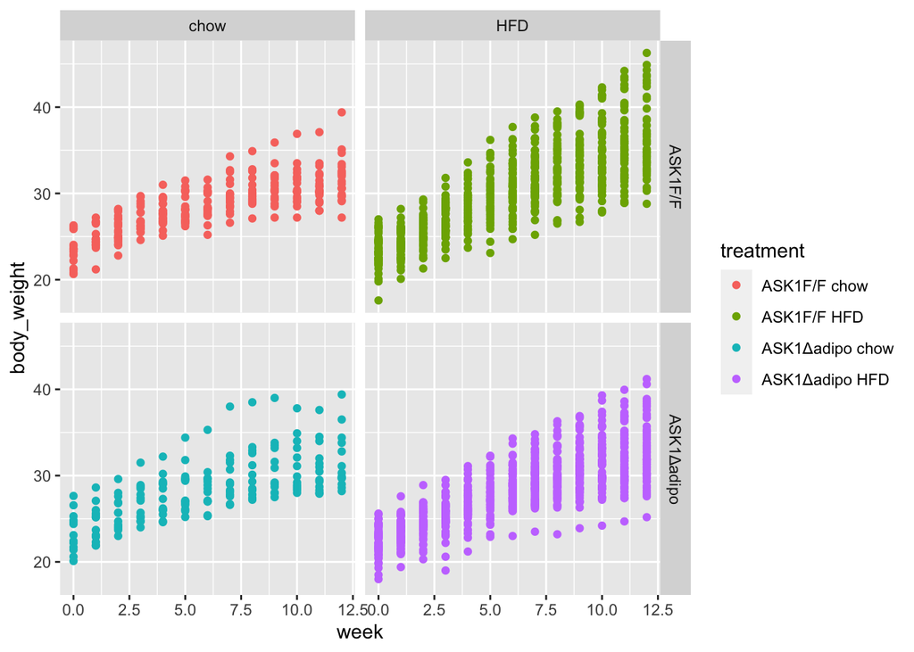

1. no obvious outliers
2. reduced growth rate at bigger size

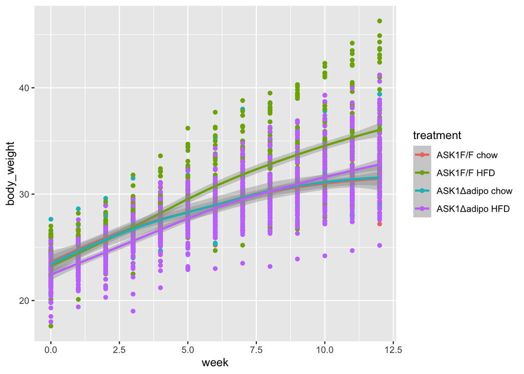

1. loess smooth. Growth in ASK1F/F + HFD clearly greater than other three treatment combinations.

## Figure 2c – Effect of ASK1 KO on final body weight

### Figure 2c – import

```
## * `` -> ...1
## * `` -> ...2
## * `` -> ...3
## * `` -> ...4
## * `` -> ...5
## * ...
```

### Figure 2c – check own computation of weight change v imported value

Note that three cases are missing from fig_2c import that are in fig_2b

### Figure 2c – exploratory plots

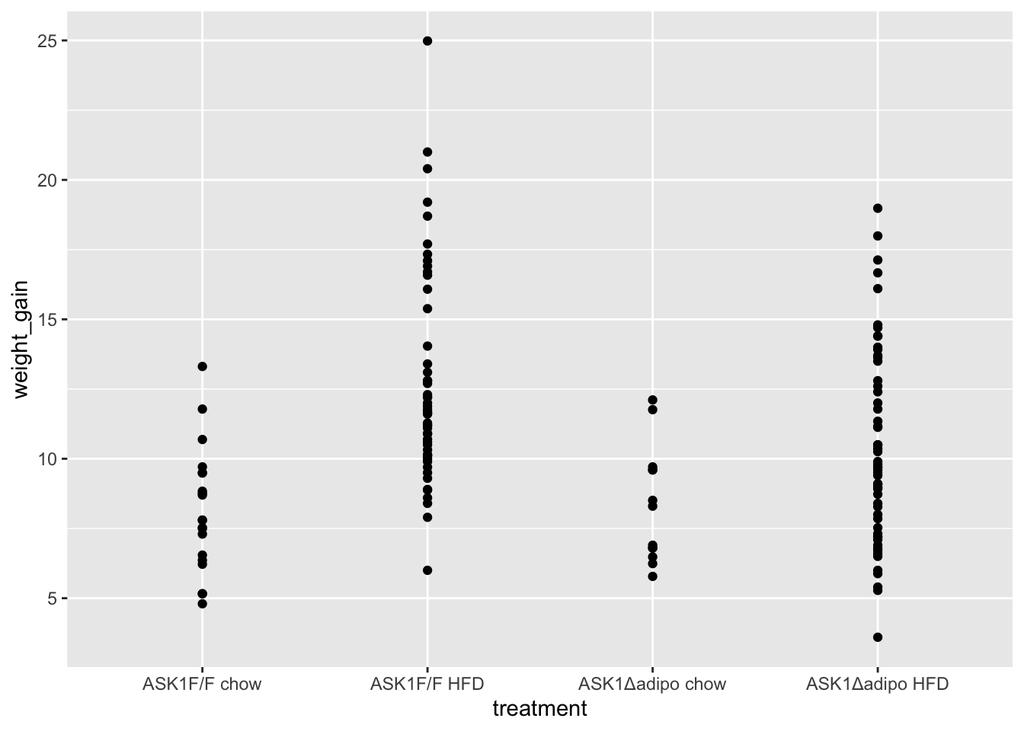

- no obvious outliers
- variance increases with mean, as expected from growth, suggests a multiplicative model. But start with simple lm.

### Figure 2c – fit the model: m1 (lm)

### Figure 2c – check the model: m1

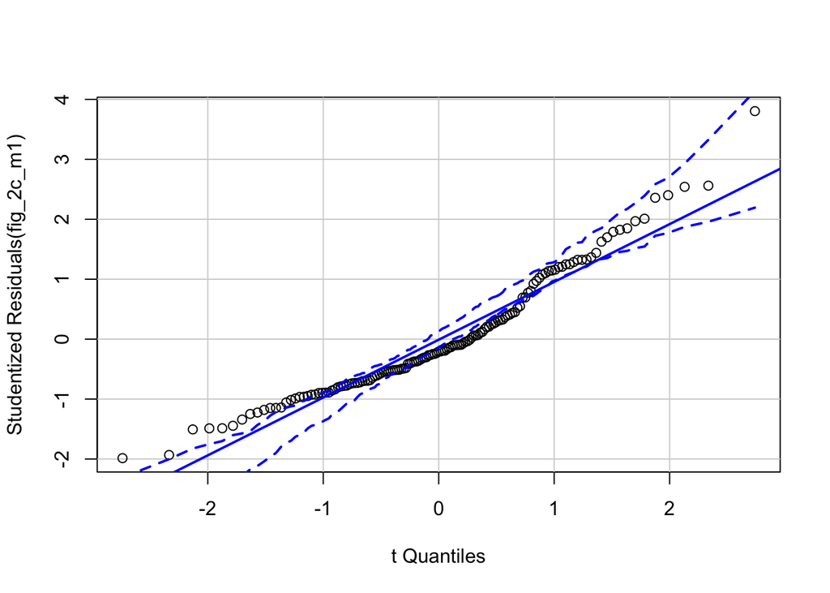

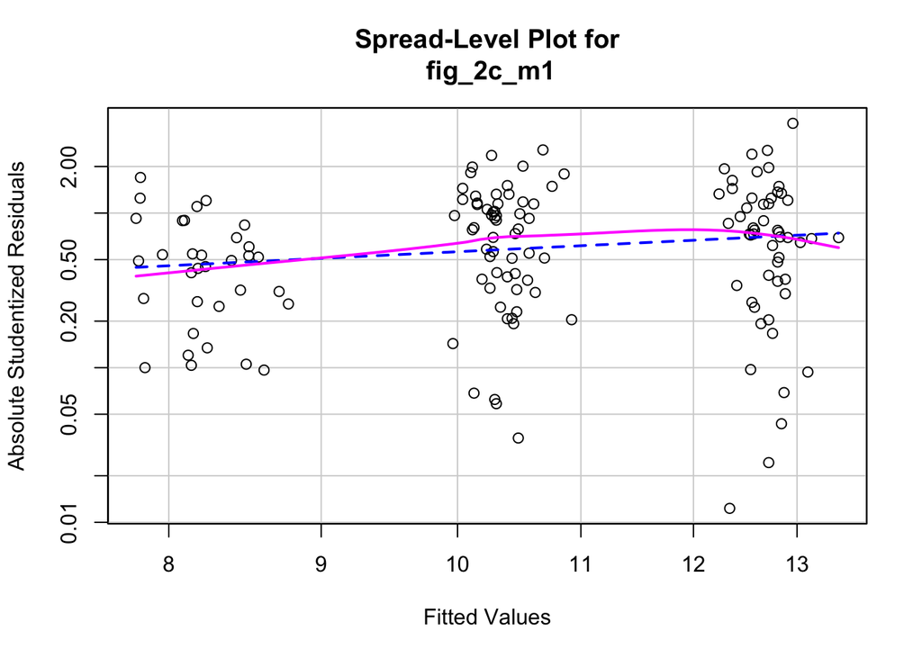

```
##
## Suggested power transformation:  0.06419448
```

- QQ indicates possible right skew but especially left side is squashed toward mean
- spread-level indicates variance increases with mean

For p-value, this may not be too severe but for intervals, best to account for this. Try gamma with log link (which makes biological sense for growth)

### Figure 2c – fit the model: m2 (gamma glm)

### Figure 2c – check the model, m2

```
## Model family was recognized or set as continuous, but duplicate values were detected in the response. Consider if you are fitting an appropriate model.
```

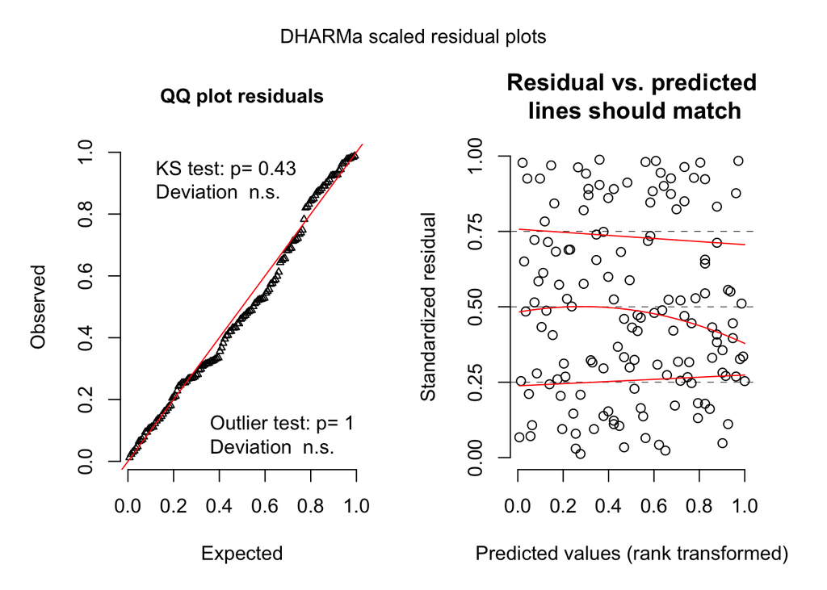

- well behaved QQ and spread-level

### Figure 2c – inference from the model

| rn | Estimate | Std. Error | t value | Pr(>\|t\|) | 2.5 % | 97.5 % |
| --- | --- | --- | --- | --- | --- | --- |
| (Intercept) | 10.87 | 0.35 | 6.83 | 0.0000 | 5.53 | 21.50 |
| week_0 | 0.99 | 0.01 | -0.84 | 0.3997 | 0.96 | 1.02 |
| ask1ASK1Δadipo | 1.03 | 0.11 | 0.24 | 0.8138 | 0.83 | 1.28 |
| dietHFD | 1.56 | 0.08 | 5.45 | 0.0000 | 1.33 | 1.82 |
| ask1ASK1Δadipo:dietHFD | 0.79 | 0.13 | -1.93 | 0.0551 | 0.61 | 1.00 |

```
##  diet ask1       response    SE  df asymp.LCL asymp.UCL
##  chow ASK1F/F        8.19 0.568 Inf      7.15      9.39
##  HFD  ASK1F/F       12.75 0.548 Inf     11.72     13.87
##  chow ASK1Δadipo     8.41 0.721 Inf      7.11      9.95
##  HFD  ASK1Δadipo    10.28 0.424 Inf      9.48     11.14
##
## Confidence level used: 0.95
## Intervals are back-transformed from the log scale
```

```
##  ask1       diet contrast             ratio     SE  df asymp.LCL asymp.UCL
##  ASK1F/F    .    HFD / chow           1.556 0.1263 Inf     1.328     1.825
##  ASK1Δadipo .    HFD / chow           1.222 0.1168 Inf     1.013     1.474
##  .          chow ASK1Δadipo / ASK1F/F 1.026 0.1127 Inf     0.828     1.273
##  .          HFD  ASK1Δadipo / ASK1F/F 0.806 0.0485 Inf     0.716     0.907
##  z.ratio p.value
##   5.453  <.0001
##   2.097  0.0360
##   0.236  0.8134
##  -3.587  0.0003
##
## Confidence level used: 0.95
## Intervals are back-transformed from the log scale
## Tests are performed on the log scale
```

```
##  diet_pairwise ask1_pairwise        ratio     SE  df asymp.LCL asymp.UCL
##  chow / HFD    ASK1F/F / ASK1Δadipo 0.785 0.0982 Inf     0.614         1
##  z.ratio p.value
##  -1.934  0.0531
##
## Confidence level used: 0.95
## Intervals are back-transformed from the log scale
## Tests are performed on the log scale
```

- the reduction in weight gain in the ASK1 KO mice compared to ASK1 CN is 0.785X. Notice that p > 0.05.

### Figure 2c – plot the model

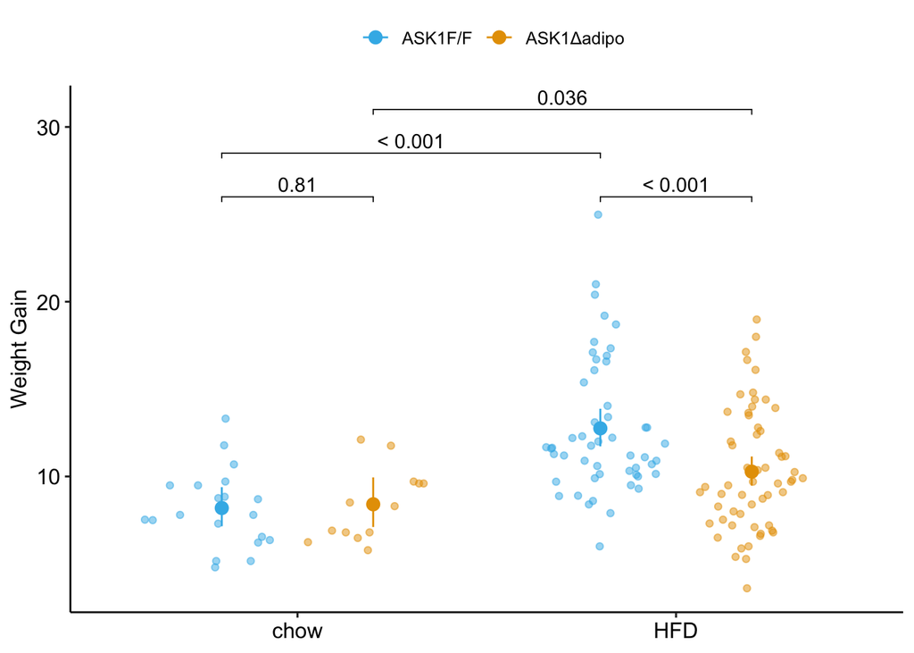

### Figure 2c – report

Results could be reported using either:

(This is inconsistent with plot, if using this, the plot should reverse what factor is on the x-axis and what factor is the grouping (color) variable) Mean weight gain in ASK1F/F mice on HFD was 1.56 (95% CI: 1.33, 1.82, $p < 0.0001$) times that of ASK1F/F mice on chow while mean weight gain in ASK1Δadipo mice on HFD was only 1.22 (95% CI: 1.01, 1.47, $p = 0.036$) times that of ASK1Δadipo mice on chow. This reduction in weight gain in ASK1Δadipo mice compared to ASK1F/F control mice was 0.79 times (95% CI; 0.61, 1.00, $p = 0.0531$).

(This is consistent with the plot in that its comparing difference in the grouping factor within each level of the factor on the x-axis) Mean weight gain in ASK1Δadipo mice on chow was trivially larger (1.03 times) than that in ASK1F/F mice on chow (95% CI: 0.83, 1.27, $p = 0.81$) while mean weight gain in ASK1Δadipo mice on HFD was smaller (0.81 times) than that in ASK1F/F control mice on HFD (95% CI: 0.72 , 0.91, $p = 0.0003$). This reduction in weight gain in ASK1Δadipo mice compared to ASK1Δadipo mice is 0.79 times (95% CI; 0.61, 1.00, $p = 0.0531$).

**note to research team**. The big difference in *p*-values between weight difference on chow and weight difference on HFD might lead one to believe there is a “difference in this difference”. Using a *p*-value = effect strategy, this is not supported.

## Figure 2d – Effect of ASK1 KO on glucose tolerance (whole curve)

### Figure 2d – Import

### Figure 2d – exploratory plots

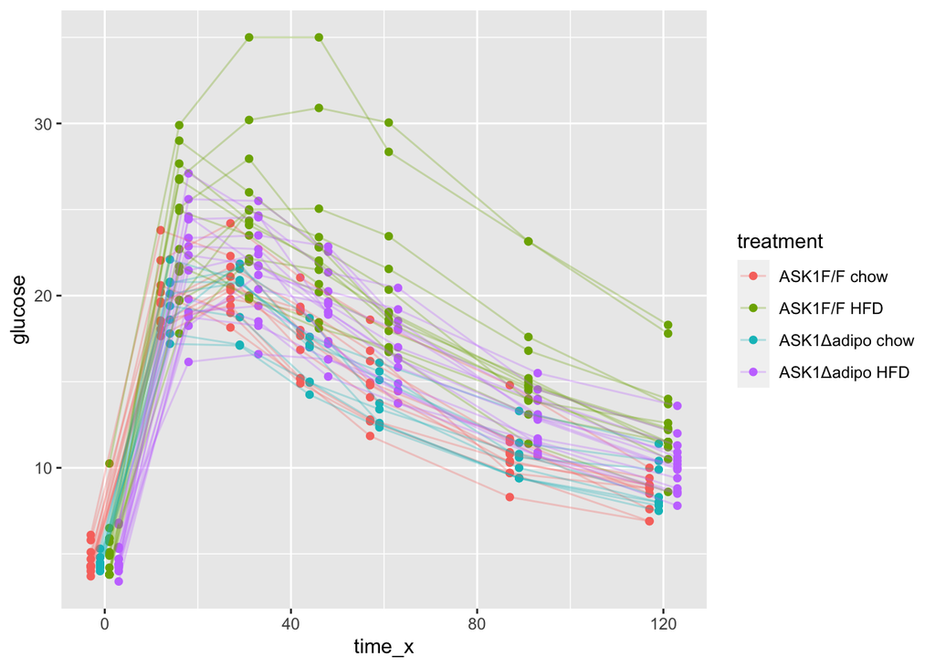

* no obvious unplausible outliers but two mice w/ high values in “F/F HFD” * similar at time zero (initial effect is trivial)

use AUC conditional on time 0 glucose

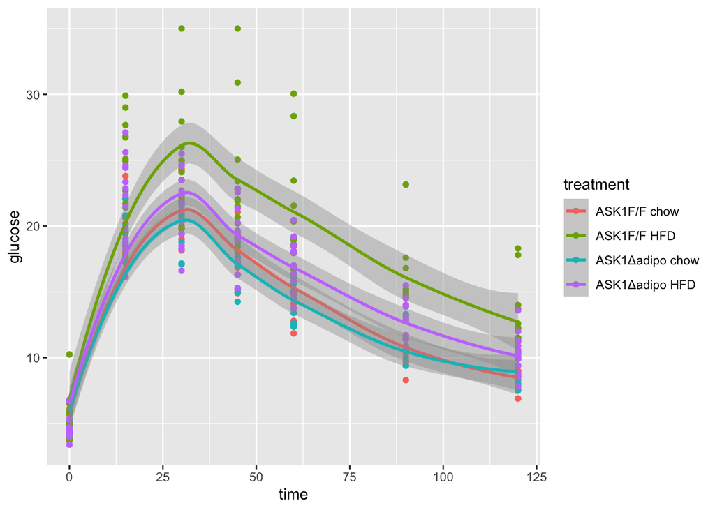

### Figure 2d – fit the model

### Figure 2d – check the model

### Figure 2d – inference

### Figure 2d – plot the model

## Figure 2e – Effect of ASK1 KO on glucose tolerance (summary measure)

The researchers did create a table to import but this analysis uses the mean post-baseline glucose amount as the response instead of the area under the curve of over the full 120 minutes. This mean is computed as the post-baseline area under the curve divided by the duration of time of the post-baseline measures (105 minutes). This analysis will use fig_2d_wide since there is only one a single Y variable per mouse.

### Figure 2e – message the data

### Figure 2e – exploratory plots

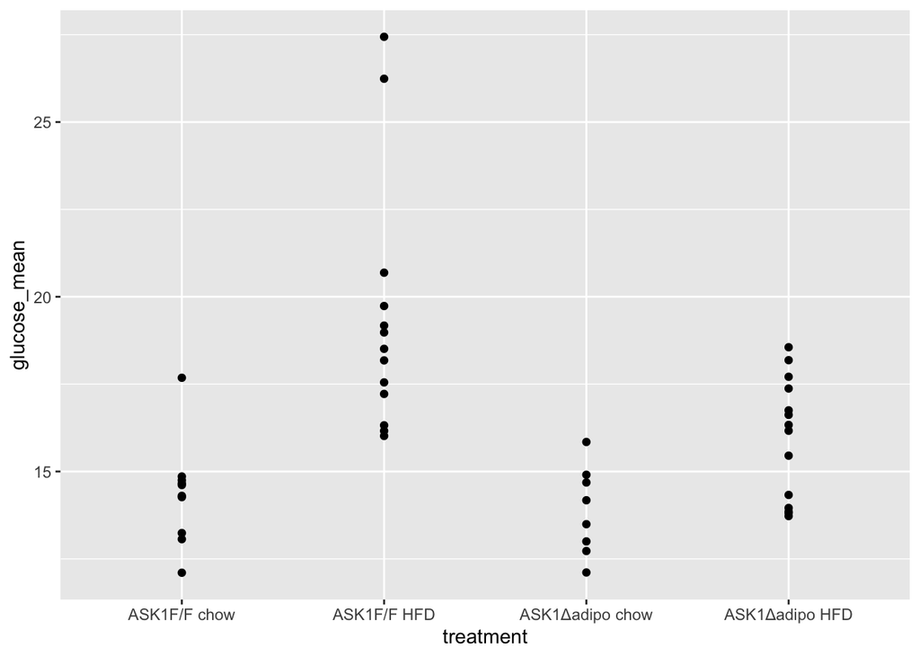

### Figure 2e – fit the model

### Figure 2e – check the model

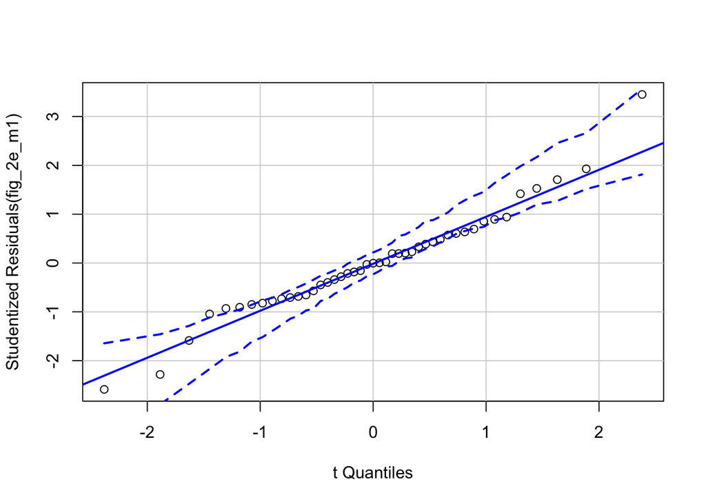

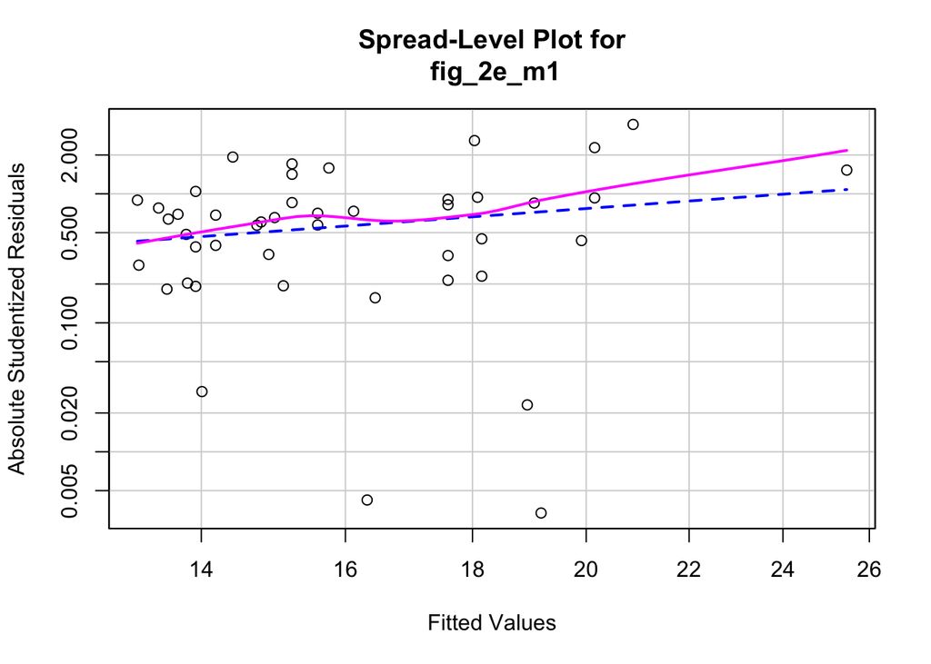

```
##
## Suggested power transformation:  -0.4035073
```

### Figure 2e – inference from the model

```
##                          Estimate Std. Error    t value     Pr(>|t|)
## (Intercept)             8.6835026  1.2556730  6.9154169 2.460045e-08
## glucose_0               1.2194720  0.2390919  5.1004329 8.592596e-06
## ask1ASK1Δadipo         -0.3488511  0.8759124 -0.3982716 6.925479e-01
## dietHFD                 4.2782121  0.7908612  5.4095613 3.185930e-06
## ask1ASK1Δadipo:dietHFD -2.7503448  1.1288320 -2.4364518 1.937783e-02
```

```
##  diet ask1       emmean    SE df lower.CL upper.CL
##  chow ASK1F/F      14.7 0.587 40     13.5     15.9
##  HFD  ASK1F/F      18.9 0.520 40     17.9     20.0
##  chow ASK1Δadipo   14.3 0.659 40     13.0     15.7
##  HFD  ASK1Δadipo   15.9 0.493 40     14.9     16.8
##
## Confidence level used: 0.95
```

```
##  ask1       diet contrast             estimate    SE df lower.CL upper.CL
##  ASK1F/F    .    HFD - chow              4.278 0.791 40    2.680     5.88
##  ASK1Δadipo .    HFD - chow              1.528 0.824 40   -0.138     3.19
##  .          chow ASK1Δadipo - ASK1F/F   -0.349 0.876 40   -2.119     1.42
##  .          HFD  ASK1Δadipo - ASK1F/F   -3.099 0.715 40   -4.544    -1.65
##  t.ratio p.value
##   5.410  <.0001
##   1.853  0.0712
##  -0.398  0.6925
##  -4.335  0.0001
##
## Confidence level used: 0.95
```

### Figure 2e – plot the model

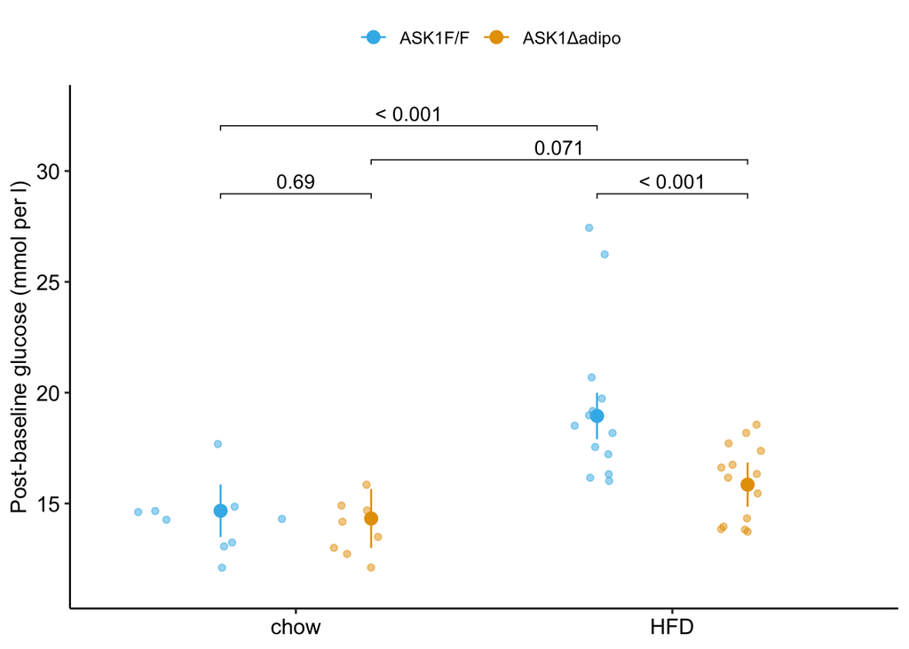

## Figure 2f – Effect of ASK1 on glucose infusion rate

### Figure 2f – import

### Figure 2f – exploratory plots

### Figure 2f – fit the model

### Figure 2f – check the model

### Figure 2f – inference

```
##  contrast             estimate  SE df lower.CL upper.CL t.ratio p.value
##  ASK1Δadipo - ASK1F/F     18.9 6.3 12     5.18     32.6 3.000   0.0111
##
## Confidence level used: 0.95
```

### Figure 2f – plot the model

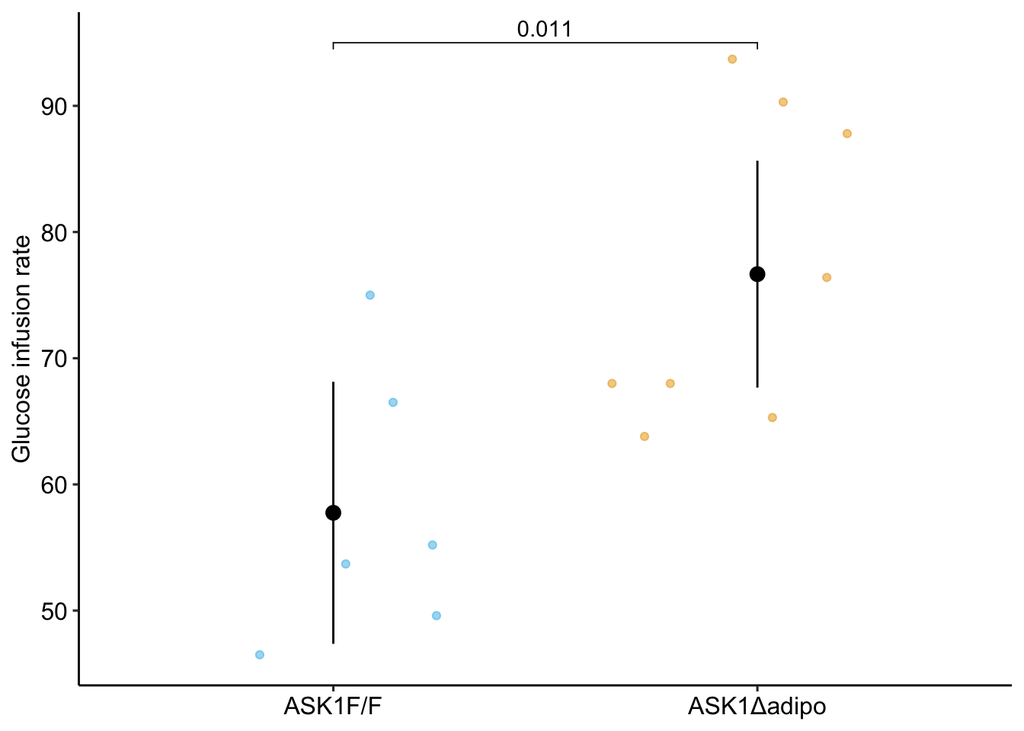

## Figure 2g

### Figure 2g – import

[output not shown]

### Figure 2g – exploratory plots

### Figure 2g – fit the model

### Figure 2g – check the model

### Figure 2g – inference

```
##    tissue             contrast  estimate        SE df     lower.CL
## 1: ingWAT ASK1Δadipo - ASK1F/F  3.595000  1.468289 10   0.32344725
## 2: epiWAT ASK1Δadipo - ASK1F/F  1.390238  0.669957 11  -0.08432738
## 3: Muscle ASK1Δadipo - ASK1F/F  2.694048  5.675468 11  -9.79757382
## 4:    BAT ASK1Δadipo - ASK1F/F 33.855000 28.715230  7 -34.04572935
##      upper.CL   t.ratio    p.value
## 1:   6.866553 2.4484273 0.03435010
## 2:   2.864804 2.0751153 0.06222096
## 3:  15.185669 0.4746829 0.64429728
## 4: 101.755729 1.1789911 0.27691810
```

### Figure 2g – plot the model

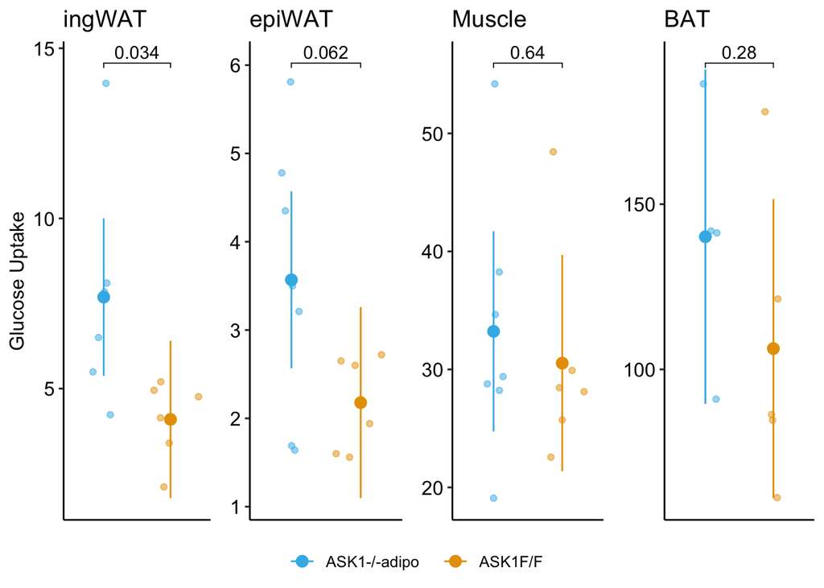

## Figure 2h

## Figure 2i

## Figure 2j